# Assignment 6

Jon Brauer & Tyeisha Fordham

10/01/2022

### Assignment 6 Objectives

#### The purpose of this sixth assignment is to help you use R to complete some of the SPSS Exercises from the end of Chapter 6 in Bachman, Paternoster, & Wilson’s [Statistics for Criminology & Criminal Justice, 5th Ed](https://edge.sagepub.com/bachmansccj5e).

This chapter provided an introduction to probability, including foundational rules of probability and probability distributions. It is likely you have heard the term “probability” before and have some intuitions about what it means. You might be surprised to learn that there are [different philosophical views](https://towardsdatascience.com/statistics-are-you-bayesian-or-frequentist-4943f953f21b) about what probability is and is not, and [our position on probability](https://www.google.com/books/edition/Bernoulli_s_Fallacy/HzQGEAAAQBAJ?hl=en&gbpv=1&dq=aubrey%20clayton%20bernoulli's%20fallacy%20chapter%201&pg=PT56&printsec=frontcover) will have important implications for the way we approach statistical description and inference!

Our book, like most undergraduate statistics books, largely presents a [frequentist](https://www.dummies.com/article/academics-the-arts/science/biology/two-views-of-probability-164627/) view of probability. It starts by presenting us with a basic frequentist mathematical definition of probability as “the number of times that a specific event can occur relative to the total number of times that any event can occur” (p.152). Keen readers will note that this definition of probability sounds uncannily similar to a *relative frequency* - that’s because it is! In frequentist statistics, [empirical probabilities](https://statisticsbyjim.com/basics/relative-frequency/) are calculated as observed relative frequencies.

However, observed (known) relative frequencies - aka empirical probabilities - often are used to do more than simply describe a sample; often, they are used to *make inferences* about unknown (theoretical) population parameters. Your book describes this long run inferential view of empirical probabilities, or what the authors call the second “sampling” notion of probability, as “the chance of an event occurring over the long run with an infinite number of trials” (p.153). Of course, we cannot actually conduct an infinite number of trials, so we use our known relative frequencies from a sample - aka our known empirical probabilities - to *infer* what we think would likely happen were we to conduct a very large number of trials. After presenting these frequentist notions of probability, the chapter moves on to explain how we could imagine a theoretical “probability distribution” of outcomes that would emerge from repeated trials of an event, then it describes various types of probability distributions, including binomial, normal, and standard normal distributions.

Recall, **descriptive statistics** involve describing characteristics of a dataset (e.g., a sample), whereas **inferential statistics** involves making inferences about a population from a subset of sample data drawn from that population. In addition to probability, this chapter also introduces the basics of **null hypothesis significance testing**, which is the most common procedure by which social scientists use frequentist empirical probabilities and probability distributions to make inferences about populations from descriptions of sample data. Hence, the materials introduced in this chapter and this assignment, including probability, probability rules, probability distributions, standard normal distributions, and standard scores (z-scores), are essential to understanding future assignments that will focus heavily on conducting and interpreting null hypothesis significance tests.

In the current assignment, you will gain a better understanding of frequentist probability by learning to create cross-tabulations or joint frequency contingency tables and calculating z-scores. As with previous assignments, you will be using R Markdown (with R & RStudio) to complete and submit your work.

#### By the end of assignment #6, you should…

- understand basic elements of a contingency table (aka crosstab)
  - understand why it can be helpful to place IV in columns and DV in rows
  - recognize column/row marginals and their overlap with univariate frequency distributions
  - know how to calculate marginal, conditional, and joint (frequentist) probabilities
  - know how to compare column percentages (when an IV is in columns of a crosstab)
- recognize the R operator `!=` as “not equal to”
- know how to turn off or change scientific notation in R, such as `options(scipen=999, digits = 3)`
- be able to remove missing observations from a variable in R using `filter(!is.na(var))`
- know how to change a numeric variable to a factor (e.g., nominal or ordinal) variable with `haven::as_factor()`
  - recognize how to drop an unused factor level (e.g., missing “Don’t know” label) on a variable using `data %>% droplevels(data$variable)`
- be able to generate a crosstab in R using `dplyr::select()` & `sjPlot::sjtab(depvar, indepvar)`
  - know how to add a title and column percents to `sjtab()` table and switch output from viewer to html browser
- be able to generate a crosstab in R using `crosstable(depvar, by=indepvar)`
  - know how to include missing data and add column/row marginal frequency totals to a `crosstable()` table
  - know how to modify decimal digits & table output format in `crosstable()` table, and how to output it to an aesthetically pleasing html table
- understand the bimomial hypothesis test and how to conduct one in R
  - understand the basic inputs of a binomial hypothesis test (p, x, *α*, & n)
- be able to modify elements of a `gt()` table, such as adding titles/subtitles with Markdown-formatted (e.g., `**bold**` or `*italicized*`) fonts
- have a basic understanding of the logic behind null hypothesis significance testing (we will continue to revisit this topic in more detail in remaining weeks)
  - understand difference between a null (test) hypothesis and contrasting alternative hypotheses
  - understand alpha or significance level (e.g., as risk tolerance or false positive error control rate)
  - recognize need to calculate a test statistic and corresponding *p*-value
  - compare a test *p*-value to alpha level and then determine whether the evidence is sufficient to reject the null hypothesis or instead should result in a failure to reject the null hypothesis
- be able to convert raw column (variable) values into standardized z-score values using `mutate()`
- know that you can create your own R functions (e.g., our `funxtoz()` function) - and that doing so is recommended for duplicate tasks to avoid copy-and-paste errors

### Assumptions & Ground Rules

#### We are building on objectives from Assignments 1-5. By the start of this assignment, you should already know how to:

#### Basic R/RStudio skills

- create an R Markdown (RMD) file and add/modify text, level headers, and R code chunks within it
- install/load R packages and use hashtags (“#”) to comment out sections of R code so it does not run
- recognize when a function is being called from a specific package using a double colon with the `package::function()` format
- read in an SPSS data file in an R code chunk using `haven::read_spss()` and assign it to an R object using an assignment (`<-`) operator
- use the `$` symbol to call a specific element (e.g., a variable, row, or column) within an object (e.g., dataframe or tibble), such as with the format `dataobject$varname`
- use a tidyverse `%>%` pipe operator to perform a sequence of actions
- knit your RMD document into an HTML file that you can then save and submit for course credit

#### Reproducibility

- use `here()` for a simple and reproducible self-referential file directory method
- Use `groundhog.library()` as an optional but recommended reproducible alternative to `library()` for loading packages

#### Data viewing & wrangling

- use the base R `head()` function to quickly view a snapshot of your data
- use the `glimpse()` function to quickly view all columns (variables) in your data
- use `sjPlot::view_df()` to quickly browse variables in a data file
- use `attr()` to identify variable and attribute value labels
- recognize when missing values are coded as `NA` for variables in your data file
- select and recode variables using dplyr’s `select()`, `mutate()`, and `if_else()` functions

#### Descriptive data analysis

- use `summarytools::dfsummary()` to quickly describe one or more variables in a data file
- create frequency tables with `sjmisc:frq()` and `summarytools::freq()` functions
- sort frequency distributions (lowest to highest/highest to lowest) with `summarytools::freq()`
- calculate measures of central tendency for a frequency distribution
  - calculate central tendency using base R functions `mean()` and `median()` (e.g., `mean(data$variable`))
  - calculate central tendency and other basic descriptive statistics for specific variables in a dataset using `summarytools::descr()` and `psych::describe()` functions
- calculate measures of dispersion for a variable distribution
  - calculate dispersion measures by hand from frequency tables you generate in R
  - calculate some measures of dispersion (e.g., standard deviation) directly in R (e.g., with `sjmisc:frq()` or `summarytools::descr()`)

#### Data visualization & aesthetics

- improve some knitted tables by piping a function’s results to `gt()` (e.g., `head(data) %>% gt()`)
- create basic graphs using ggplot2’s `ggplot()` function
  - generate simple bar charts and histograms to visualize shape and central tendency of a frequency distribution
  - generate boxplots using base R `boxplot()` and `ggplot()` to visualize dispersion in a data distribution
- modify elements of a ggplot object
  - change outline and fill colors in a ggplot geometric object (e.g., `geom_boxplot()`) by adding `fill=` and `color=` followed by specific color names (e.g., “orange”) or hexidecimal codes (e.g., “#990000” for crimson; “#EDEBEB” for cream)
  - add or change a preset theme (e.g., `+ theme_minimal()`) to a ggplot object to conveniently modify certain plot elements (e.g., white background color)
  - select colors from a colorblind accessible palette (e.g., using `viridisLite::viridis()`) and specify them for the outline and fill colors in a ggplot geometric object (e.g., `geom_boxplot()`)
  - add a title (and subtitle or caption) to a ggplot object by adding a label with the `labs()` function (e.g., `+ labs(title = "My Title")`)

*If you do not recall how to do these things, review Assignments 1-5.*

Additionally, you should have read the assigned book chapter and reviewed the SPSS questions that correspond to this assignment, and you should have completed any other course materials (e.g., videos; readings) assigned for this week before attempting this R assignment. In particular, for this week, I assume you understand:

- difference between descriptive and inferential statistics
- z-scores
  - formula for converting a raw score into a z-score
  - how use a z-score table
- how to calculate conditional probabilities from a frequency table or cross-tabulation
- rules of probabilities
  - bounding rule (rule #1; 0 to 1)
  - restricted and general addition rules of probabilities (rule #2a & #2b; unions)
  - restricted and general multiplication rules of probability (rule #3a & #3b; intersections)
- probability of an event or the complement of an event
  - independent and mutually exclusive events
  - probability of success - binomial theorem
- probability distributions
  - binomial, normal, and standard normal distributions
  - formula for normal distribution
  - sampling distributions
- logic underlying null hypothesis testing
  - null hypothesis
  - alpha level (level of significance)
  - z-scores and critical regions
  - reject or failure to reject null

As noted previously, for this and all future assignments, you MUST type all commands in by hand. *Do not copy & paste except for troubleshooting purposes (i.e., if you cannot figure out what you mistyped).*

### Part 1 (Assignment 6.1)

#### Goal: Read in NCVS and 2012 States Data

*(**Note:* *Remember that, when following instructions, always substitute “LastName” for your own last name and substitute YEAR_MO_DY for the actual date. E.g., **2022_06_15_Fordham_K300Assign6**)*

In the last assignment, you learned how to use frequency tables to calculate measures of dispersion and boxplots to visualize dispersion in a frequency distribution. In this assignment, you will learn the basics of probability theory and probability distributions, including binomial and normal distributions. You will also learn about how to covert a raw score into a standard score or z-score using the standard normal distribution, as well as how such standard scores are used to test null hypotheses with the goal of making population inferences from sample data.

For many, probability is one of the most difficult things to understand in statistics. Some probability calculations are quite intuitive, while others seem to defy our intuitions. As you read Chapter 6 and watched this week’s videos, hopefully you began to understand how probability theory underlies inferential statistics and allows us to make claims about larger populations from sample data. We will continue to work toward understanding inferential statistics over the next few assignments. In this assignment, we will practice calculating (frequentist) probabilities and using z-scores.

```r
StatesData <- read_spss(here("Datasets", "2012StatesData.sav"))
NCVSData <- read_spss(here("Datasets", "NCVSLoneOffenderAssaults1992to2013.sav"))
```

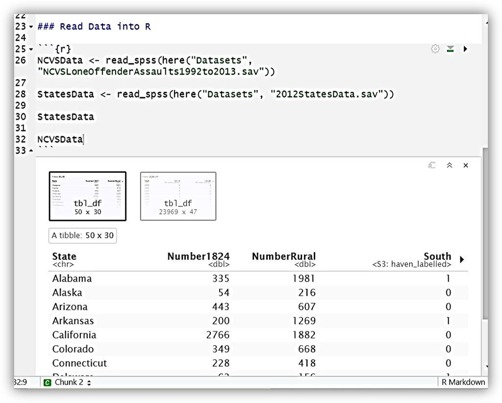

View NCVS and States Data

### Explaining Cross-tabulations

#### Goal: Understand basic elements of a contingency table

In the next section, we will generate contingency tables - otherwise known as a “cross-tabulations” or crosstabs - and use them to calculate (frequentist) marginal, conditional, and joint probabilities.

Contingency tables or cross-tabulations are useful for understanding the association (or lack thereof) between two or more variables. Specifically, we will cross-tabulate two variables from the National Crime Victimization Survey data (`NCVSData`): the ordinal variable ‘relationship’, capturing a victim’s relationship to their assailant (0=“total stranger” to 3=“well known”), and the binary variable ‘maleoff’, representing the sex of the offender (0=female; 1=male). Before we do this together, let’s cover the basic elements of a contingency table.

1. Until now, we have focused primarily on univariate descriptive statistics that summarize characteristics of a frequency distribution for a single variable in a sample, such as the relative frequency or probability of a particular value, or the distribution’s central tendency, shape, or dispersion. Let’s pick a couple variables from the NCVS data - ‘privatelocation’ and ‘reportedtopolice’ and start by generating their univariate frequency distributions.
   1. Recall, these NCVS data contain survey responses about individuals’ experiences with criminal victimation collected from nationally representative samples of people in U.S. households. This particular subset contains data from the 1992 to 2013 NCVS studies and only includes data from respondents who reported either violent or nonviolent assault by a single offender. For more information, see p.191 in Bachman, Paternoster, & Wilson’s book.
   2. For this example, we selected these two variables to illustrate how a cross-tabulation might help us answer the following research question: *Are criminal victimizations that occur in private locations more or less likely to be reported to police than victimizations that do not occur in private locations?*
      - ‘privatelocation’ is a dummy variable (i.e., 0 or 1 values) indicating whether the reported victimization occurred in a private location (0=*Not a private location*; 1=*Private location*).
      - ‘reportedtopolice’ is a dummy variable indicating whether the victimization incident was reported to the police (0=*Unreported*; 1=*Reported*).
      - Remember, you can check these details using `sjplot::view_df()` (e.g., by typing `NCVSData %>% viewdf()`).
   3. Below are the univariate frequency distributions for the ‘privatelocation’ and ‘reportedtopolice’ variables in our NCVS data subset.

```r
NCVSData %>%
  filter(!is.na(reportedtopolice)) %>%
  freq(privatelocation, report.nas = TRUE) %>%
  tb() %>%
  gt()
```

| privatelocation | freq | pct_valid | pct_valid_cum | pct_tot | pct_tot_cum |
| --- | --- | --- | --- | --- | --- |
| 0 | 17618 | 76.2354 | 76.2354 | 76.2354 | 76.2354 |
| 1 | 5492 | 23.7646 | 100.0000 | 23.7646 | 100.0000 |
| <NA> | 0 | NA | NA | 0.0000 | 100.0000 |

```r
NCVSData %>%
  filter(!is.na(reportedtopolice)) %>%
  freq(reportedtopolice, report.nas = TRUE) %>%
  tb() %>%
  gt()
```

| reportedtopolice | freq | pct_valid | pct_valid_cum | pct_tot | pct_tot_cum |
| --- | --- | --- | --- | --- | --- |
| 0 | 12639 | 54.69061 | 54.69061 | 54.69061 | 54.69061 |
| 1 | 10471 | 45.30939 | 100.00000 | 45.30939 | 100.00000 |
| <NA> | 0 | NA | NA | 0.00000 | 100.00000 |

```r
#The following code more efficiently accomplishes the same goal
# NCVSData %>% freq(reportedtopolice, report.nas = TRUE) %>% tb() %>% gt()
```

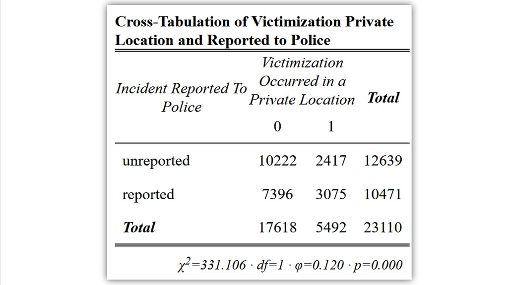

Contingency table w/frequencies

4. Recall, our research question: *Are criminal victimizations that occur in private locations more or less likely to be reported to police than victimizations that do not occur in private locations?* This question implies that ‘privatelocation’ is the **independent variable (IV)** and ‘reportedtopolice’ is the **dependent variable (DV)** In other words, we hypothesize that whether or not a victimization is reported to police depends at least in part on the location of the victimization.
   1. Logically, it does not make sense to posit that police reporting causes victimization location.
   2. Meanwhile, even if it is associated, victimization location may not have a direct causal relationship with with police reporting, as such an association could reflect unmeasured confounding or mediating mechanisms (e.g., systematic differences in victim/offender relationships or offense types across locations might actually cause differences in police reporting). Hence, association `!=` causation.
      - Note the `!=` is an operator in R that means “not equal to”. Recall, we also used `!` earlier prior to `is.na` when filtering missing data. While `is.na` means “is missing”, `!is.na` means “not is missing” or “not NA”).
   3. We might even expect and test more specific directional expectations for the posited association, such as that victimizations occurring in private locations are *less likely* to be reported to police than victimizations not occurring in private locations. For now, we will stick with a basic non-directional hypothesized association.
5. In any case, we prefer to **generate contingency tables that place the IV on top with its frequencies in the columns and the DV on the side with its frequencies in the rows**. While this is a preference, following a consistent practice like this will make it much easier to read contingency tables and result in fewer errors.
   1. Since ‘privatelocation’ is the independent variable (IV) here, you will note that it is placed in the columns of the contingency table; see the yellow highlighted section in the image below.
   2. Meanwhile, ‘reportedtopolice’ is the dependent variable, so it is placed in the rows of the contingency table; see the purple highlighted section in the image below.

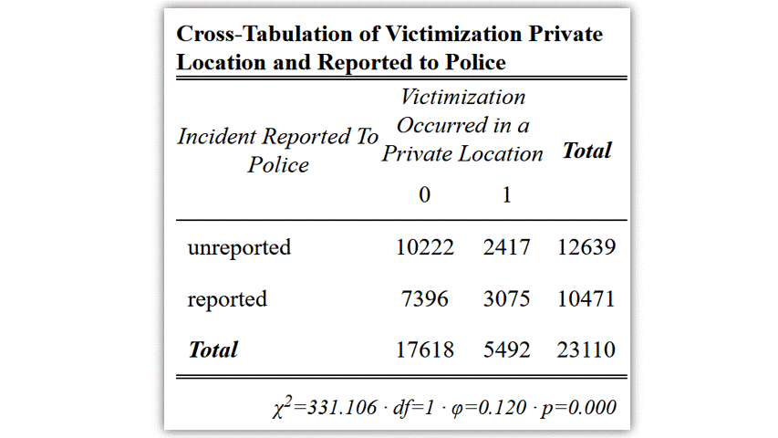

I recommend IV in columns & DV in rows

6. The frequency values at the bottom of the IV’s columns and the end of the DV’s rows, respectively, are known as column and row “marginal frequencies” or marginals for short; see the yellow (column marginals) and purple (row marginals) frequency values in the image below. If you compare these to our univariate frequency distribution tables above, you will notice the marginal frequencies match the univariate frequency distribution values (after using filter to remove `NA` values).

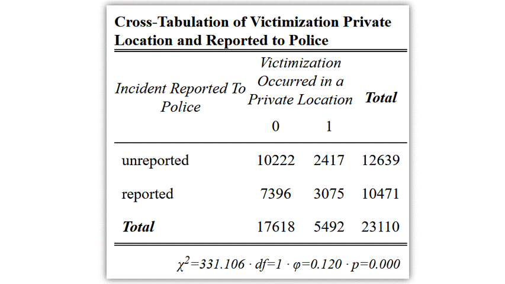

Column & Row Marginal Frequencies

7. So, we can identify univariate frequency distributions from the marginal frequencies (row or column totals) in a contingency table. In addition, a cross-tabulation presents joint frequencies - see the overlapping highlighted section containing joint frequency values in the image below.

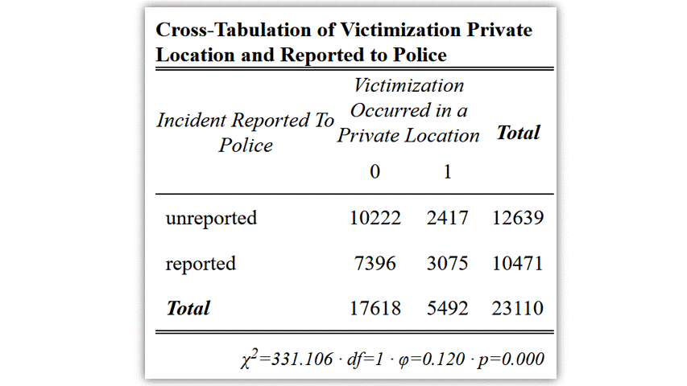

Joint Frequencies

8. We can extract a lot of useful information from joint frequencies in a contingency table. For example, we know that 5,492 (column marginal) of the 23,110 (total) victimizations in the data reportedly occurred in a private location. Of those 5,492 private victimizations, 3,075 were reported to police and 2,417 were unreported.
   1. From these joint frequencies, we can easily calculate marginal, joint, or conditional relative frequencies (aka, frequentist probabilities) - we just divide the desired marginal or joint frequency by the total (for marginal or joint) or row/column (for conditional) frequency, respectively.
      - For example, the marginal probability of a crime being reported is p(reported)=0.45 (i.e., 10,471/23,110). Note that this marginal probability (aka, marginal relative frequency) is independent of the values of the other (‘private’) variable.
      - The conditional probability of an assault being reported given it occurred in a private location is p(reported|private)=0.56 (i.e., 3,075/5,492). Note that this conditional probability depends on - it is conditional on - the value of the ‘private’ variable (i.e., ‘private’ = 1).
      - The conditional probability of an assault *not* being reported given it occurred in a private location is p(unreported|private) = 0.44 (i.e., 2,417/5,492). Note that you could also calculate this probability by subtracting its *complement*, which we just calculated above (i.e., 1-0.56).
      - The joint probability of an assault occurring in a private location and being unreported is p(private⋂unreported)=0.10 (i.e., 2,417/23,110).
   2. You will practice calculating probabilities like these later in the assignment when answering question 2 from the Chapter 6 SPSS exercises. When you do, remember that it is very easy to read and calcualte these relative frequencies or probabilities incorrectly, such as by selecting and dividing by the wrong frequency value (e.g., row instead of column, or total instead of row or column). To avoid such mistakes, take your time, be sure you know what it is you want to describe in the data, and be consistent in constructing tables (e.g., always placing your IV in the columns will help a lot!).

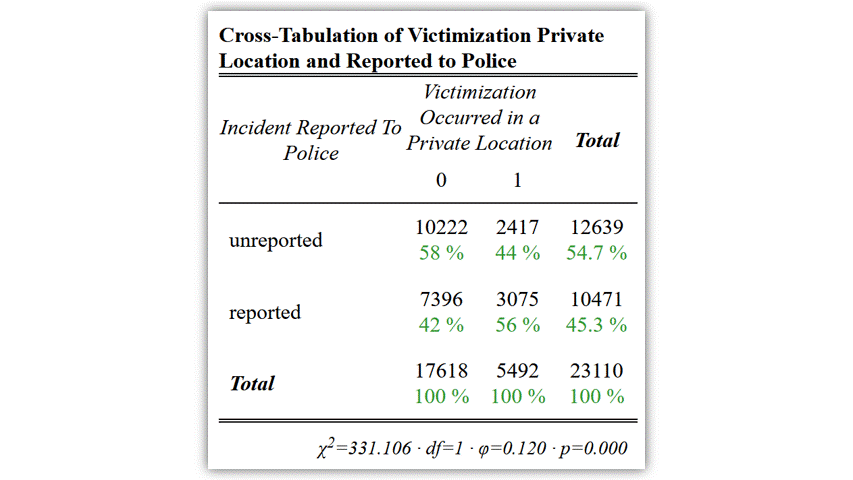

Comparing column percentages

9. In addition to joint frequency distributions, it is also common to see percentage values reported in contingency tables. Once again, it is important to be sure the calculated or reported percentages *are the percentages that you want* when reading and interpreting the table. If we stick with the recommended practice of placing our IV in the columns, then we often want **column percentages** (as opposed to row percentages). The image above includes column percentages directly beneath the frequencies. With this table setup and with column percentages, we will usually **total down and compare across** when assessing a relationship between the IV and the DV.
   1. If set up and calculated correctly, column percentages should **total down** within a column to 100%.
      - This means that when column percentages are reported, the column percents should add to 100% and the column marginals at the bottom of the table should show (or calculate to) 100% as well.
      - However, these percentages usually will NOT add up to 100% within a row; you can see this in the image after, where the percentages reported in the row marginals do not equal 100%.
   2. If set up and calculated correctly, column percentages are usually **compared across** columns of the IV and within a row of the DV.
      - For example, the table above shows 56% of the victimizations that occurred in private locations were reported to the police.
      - In comparison (i.e., compare within same row of the DV), 42% of victimizations that did not occur in private places were reported to police.
   3. Recall from the univariate frequency distributions and our column marginal frequencies that victimizations in private locations are relatively rare, with only about 24% occurring in private locations (i.e., 5,492/23,110). Now, from a comparison of joint frequencies and column percentages in our contingency table, we can conclude that victimizations occurring in private locations are somewhat *more likely* to be reported to police compared to those not occurring in private locations (56% versus 42% respectively).
      - Put differently, there is an association between these two variables: victimizations occurring in private locations are *less likely* to go unreported than are victimizations occurring in other places (44% versus 58%, respectively).
10. In addition to making percentage comparisons, we can also test the null hypothesis that victimization location is unrelated to police reporting. For instance, we could conduct a chi-square test of statistical independence to make inferences about the existence of a relationship in the population from which this sample was drawn. We could also calculate proportional reduction in error (PRE) measures, such as Phi or Cramer’s V, to statistically summarize the strength of association in standardized terms. Later in this assignment, you will learn to perform a binomial hypothesis test, which is also useful and appropriate in certain circumstances. - For this course, we will rarely use Cramer’s V, but we will learn about that measure and chi-square tests later. For now, if you would like some background on chi-square tests, you could check out [this website](https://www.simplypsychology.org/chi-square.html). - For more information on cross-tabulations in general, you might find [this website to be helpful](https://www.surveyking.com/help/cross-tabulation-analysis).

### Part 2 (Assignment 6.2)

#### Goal: Create Cross-Tabulations of sex (“V3018”) and “relationship” variables

You will learn to use two functions to generate contingency tables like those presented above. First, the `sjtab()` function [from the “sjPlot” package](http://www.strengejacke.de/sjPlot/reference/sjplot.html), which was used to create the tables above, is a tidyverse-friendly option for creating useful and aesthetically pleasing contingency tables (for more details, see [here](https://strengejacke.wordpress.com/2016/11/14/pipe-friendly-workflow-with-sjplot-sjmisc-and-sjstats-part-1-rstats-tidyverse/), [here](https://strengejacke.wordpress.com/2017/03/05/direct-integration-of-sjplot-tables-in-knitr-rmarkdown-documents-rstats/) and [here](https://strengejacke.wordpress.com/2014/02/20/no-need-for-spss-beautiful-output-in-r-rstats/). With the `sjtab()` approach, we will also rely on the `select()` function, which we have used before, to select the specific variables we want to include in our contingency table.

Second, the `crosstable()` function from [the “crosstable” package](https://danchaltiel.github.io/crosstable/articles/crosstable.html) is another tidyverse-friendly way to generate useful and aesthetically pleasing contingency tables. In addition to [generating contingency tables](https://danchaltiel.github.io/crosstable/articles/crosstable.html) with numerous customizing options, you can use the package to generate univariate and grouped descriptive statistics, bivariate correlations, bivariate effect sizes, and more! Moreover, this package has the advantage of printing beautiful HTML tables directly in your RMD document rather than outputting them to the viewer pane. We will learn to use this package in the next section.

Let’s start by using the `sjtab()` package to generate a table that will help us answer question 2 (part a [i-iii] & part b [i-ii]) from the SPSS exercises at the end of Chapter 6 (p.192) of the book. This question requires us to generate a contingency table of ‘relationship’ (victim’s relationship to assailant) by ‘V3018’ (victim’s sex) to assess whether there are gender differences in victims’ relationships to their assailants. For instance, a contingency table might help us determine whether the probability of being assaulted by a stranger or by a well-known acquaintance is equivalent or differs for men and women.

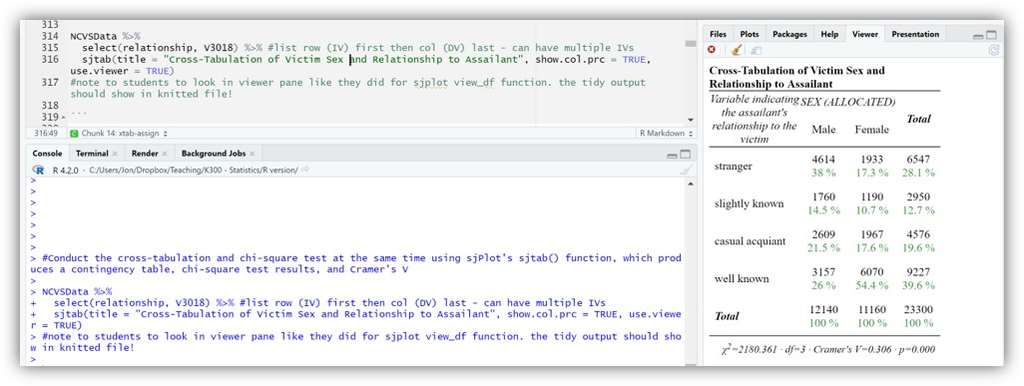

Crosstab of Victim Gender and Relationship to Assailant

5. You generated a tidy crosstab with column percentages (plus a Chi-squared test & Cramer’s V)!
   1. Depending on the options you selected, it should have populated in your viewer pane or in a pop-up browser window. In either case, it should knit to your final HTML. Try knitting now just to make sure.
   2. Now, go to the Chapter 6 SPSS exercises on p.192 of the book, then use your table to answer question 2, part a (i-iii) and part b (i-ii only).
      - *Note:* To answer these questions, you should use the **frequency** values in your table to calculate the requested probabilities.

#### Optional: Alternative Crosstab Method

#### Goal: Learn alternative method to create cross-tab of sex (“V3018”) and “relationship”

Before moving on, we will show you how to generate a similar contingency table using the `crosstable()` function from the “crosstable” package. This part of the assignment is optional, though feel free to follow along in your own RMD file.

1. Before generating our table using `crosstable()`, the first thing we need to do is modify our ‘relationship’ variable.
   1. By default, the `crosstab()` function views variables with three or more numbered values - like our relationship variable, which has four values ranging from “0” to “3” - as a numeric variable. With numeric variables, the function’s default action is to output descriptive statistics rather than a contingency table. So, to generate a cross-tab, we will first need to transform ‘relationship’ into a factor variable.
   2. Additionally, the variable has a user-defined factor label (“Don’t know”) associated with missing `NA` values. We could simply generate the table and include a row for “Don’t know.” However, we will add a couple more steps to drop these `NA` values so our table exactly matches the one we generated using `sjtab()` above.
   3. Click the code button below to see how we did this.

```r
NCVSData2 <- NCVSData %>%
  filter(!is.na(relationship)) %>%
  mutate(relationshipfac = haven::as_factor(relationship))

NCVSData2 <- NCVSData2 %>% droplevels(NCVSData2$relationshipfac)
```

2. Now, let’s break down the code.
   1. First, we assign our data and manipulations into a new data object (`NCVSData2 <- NCVSData`).
      - I prefer to do this when performing several sequential data wrangling steps. This way, I can perform data manipulations on the new file while preserving our original data.
   2. Next, we piped our data to a `filter()` command. You should recognize this - we used it earlier in the assignment in the section explaining crosstabs. Here, we filtered the data to drop missing values on the ‘relationship’ variable (`filter(!is.na(relationship))`).
      - Normally, I would not recommend simply deleting missing values. It is better to keep them in the data, examine missing data and its source(s), and use a principled approach to handling missing data.
      - For now, we will simply drop the missing data since our goal is to reproduce the `sjtab()` table generated above, which removed missing data by default to perform basic statistical procedures (e.g., Chi-squared test of independence; Cramer’s *V* calculation).
   3. We then piped our filter statement to a `mutate()` command. In this line, we transformed our old ‘relationship’ variable into a factor using the `haven::as_factor()` function and assigned it to a new variable called ‘relationshipfac’ (`mutate(relationshipfac = haven::as_factor(relationship))`).
      - Note that we explicitly called the “haven” package (`haven::as_factor`). This is because there are other popular packages (e.g., “sjlabelled”; “forcats”) that also use the same function. Recall, we will sometimes do this with `dplyr::select()` for similar reasons.
   4. Finally, we pipe our mutate statement to a `droplevels()` command. If we omit this line, our crosstab will display an empty row for the “Don’t know” (`NA`) response option. Remember, we filtered out the “Don’t know” values. This statement now tells R to drop the unused (empty) factor level.
3. After these data wrangling steps, we are ready to use the `crosstable()` function! Click the “code” button to see how the sausage is made.

```r
NCVSData2 %>%
  crosstable(relationshipfac, by=V3018, showNA="ifany", total="both",
           percent_digits=1, percent_pattern="{n} ({p_col})") %>%
    as_flextable(keep_id=FALSE)
```

[output not shown]

4. As before, let’s break down this code.
   1. Recall, we are generating a table for relationship *by* sex so, as with `sjtab()`, we will specify our DV (‘relationship’) first, then list our IV second (i.e., `by=V3018`).
   2. `showNA="ifany"` would include our `NA` (“Don’t know”) values had we not filtered them out and dropped the factor level. While this is a useful toggling option for showing or omitting `NA` values, selecting “no” does not change the total N, meaning our percentages would not have matched the table we created earlier. You can see what I mean by simply changing the code to instead specify our original data (i.e., to `NCVSData`) and our original dependent variable (`relationship`), then running the `crosstab()` code again.
   3. `total="both"` adds row and column marginal totals. You can select both, row, column, or none.
   4. `percent_digits=1` outputs percentage values to the one decimal place. You can choose your level of precision or select no decimals (`0`).
   5. `percent_pattern="{n} ({p_col})")` controls what values are included in the table and how those values are formatted. In this case, we requested the frequency values (`{n}`) followed by the column percentages in parentheses (`({p_col})`).
   6. `%>% as_flextable(keep_id=FALSE)` converts the default table into a more aesthetically pleasing HTML table. The `keep_id=FALSE` drops the first column with the variable name; in this case, the `id` column and the variable `label` column were redundant. *Note:* If you want, you could replace this line with a pipe to `gt()` instead.
5. Now you know two different ways to generate crosstabs, and you learned a little more about data wrangling along the way! Let’s move on to learn how to conduct a binomial hypothesis test.

### Part 3 (Assignment 6.3)

#### Goal: Conduct a binomial hypothesis test

In this next section, you will learn how to answer question 3 on page 192 of B&P’s Chapter 6. While the last question focused on the victim’s sex and relationship to assailant, this question focuses instead on the offender’s sex. Specifically, the question asks you to conduct a binomial hypothesis test to infer whether women are more likely than men to assault someone else in the U.S. population.

To test this hypothesis, we will use the ‘maleoff’ variable, which records victims’ reports of the sex of the offender (0=female offender; 1=male offender), to generate relative frequency/proportion values for male and female offenders. We will then use the binomial distribution to test how probable the observed proportions would be under a null hypothesis of no sex differences in offending (i.e., p=0.50).

You can find a detailed description and example application of the binomial hypothesis test on pages 165-172 of the book. [Check out this helpful resource](https://crumplab.com/rstatsforpsych/binomial-test.html) for another description of the binomial test and an alternative way of conducting it in R. Put briefly, here is the essential process:

- If we have data on the number of “successes” (‘x’ or the number of assaults by women in this case) in a fixed number of trials (‘n’, total sample size, or the total number of assaults in this case), then we can use the binomial distribution to calculate the joint probability (summarized by a *p*-value) that the binary event (success or fail; 0 or 1) would occur *as or more frequently* than we observed given a pre-determined null hypothesis. We then compare our *p*-value from the binomial test to our pre-specified alpha level (*α*).
- If our test *p*-value > *α* then we would conclude there is not enough evidence to reject the null hypothesis; that is, we would **fail to reject the null hypothesis**.
- Alternatively, if our test *p*-value < *α*, then we would conclude that it would be highly unlikely to observe a relative frequency/probability (of assault by women) as or more extreme than the one we observed *if the null hypothesis were true* in the population. Likewise, we would conclude that there is enough evidence to **reject the null hypothesis**.
- So, to conduct a bimomial hypothesis test, we need:
  1. ‘p’, or the null hypothesized (prior) probability of success (not to be confused with *p*-value!)
  2. ‘*α*’, or the alpha level
  3. ‘x’, or the number of trials or observations we are analyzing (i.e., number of assaults by women)
  4. ‘n’, or the total number of observations (i.e., total number of assaults)

Now that we know what we need, let’s get to work.

```r
# NCVSData %>% frq(maleoff)
NCVSData %>% freq(maleoff)
```

```
## Frequencies
## NCVSData$maleoff
## Label: Male offender =1, 0=female offender
## Type: Numeric
##
##                Freq   % Valid   % Valid Cum.   % Total   % Total Cum.
## ----------- ------- --------- -------------- --------- --------------
##           0    4798     20.02          20.02     20.02          20.02
##           1   19171     79.98         100.00     79.98         100.00
##        <NA>       0                               0.00         100.00
##       Total   23969    100.00         100.00    100.00         100.00
```

5. Now that we have all the inputs we need, we can use the binomial test function from the “rstatix” package we installed to conduct the hypothesis test.
   1. Insert an R chunk and type `binom_test(x = 4798, n = 23969, p = .5)` on one line.
      - `binom_test()` is the function that runs binomial hypothesis tests in the “rstatix” package. Within this function, we are specifying `x = 4798`, `n = 23969`, and `p = .5`.
      - If you want, you can assign the binomial test to an object (e.g., use `<-` and perhaps call it `binomtestfemoff`). Then, you can click the object in your environment and see it in a new tab.
   2. Your RStudio should look something like this:

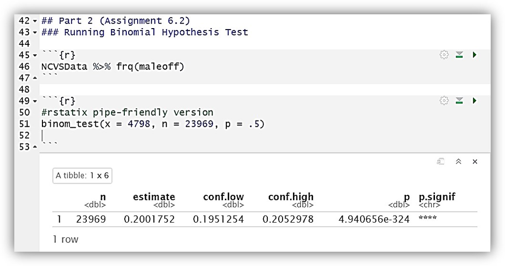

Binomial Test of Assailant Gender

6. We are not quite done! Let’s make this binomial test output a bit more visually appealing and easier to read by piping it to the `gt()` function.
   1. Remember, `gt()` allows us to create beautiful tables that are more accessible and intuitive to read.
   2. To do this, you simply type `%>%` (a pipe) after `binom_test(x = 4798, n = 23969, p = .5)`. Then, hit enter and type `gt()`.
   3. If you run your chunk now, your RStudio session should look something like this:

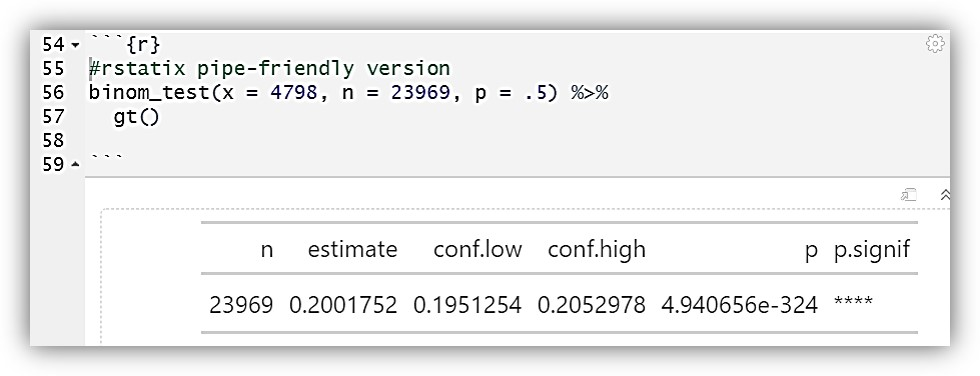

Binomial Test with ‘gt’ Package

7. Now is a good time to show you how to customize tables using `gt()`. You can do all sorts of custom modifications; some examples include: adding titles, subtitles, and note lines; changing column or value labels; and making fonts bold, italicized, or underlined. To give you a sense of how this works, we will add a title and subtitle to our table.
   1. Add another pipe (%>%) after `gt()`, then hit enter
   2. On the next line, type `tab_header(` then hit enter
   3. On the next line, type `title = md("**Binomial test of sex differences in assaults using NCVS subset**"),` then hit enter
   4. On the next line, type `subtitle = md("*H0:* p=0.50, x(female assaults)=4,798, n=23,969"))`
      - `tab_header()` adds/modifies a [table header](https://gt.rstudio.com/reference/tab_header.html).
      - `md()` specifies our text input as [Markdown-formatted text](https://gt.rstudio.com/reference/md.html), which allows us to bold the `**title**` using double asterisks and italicize `*H0:*` with single asterisks.
   5. Run your code chunk, then use your new gt-modified table to interpret results from your binomial hypothesis test.

```r
# options(scipen=999, digits = 3 )
# options(scipen=10, digits = 3 )

binom_test(x = 4798, n = 23969, p = .5) %>%
  gt() %>%
    tab_header(
      title = md("**Binomial test of sex differences in assaults using NCVS subset**"),
      subtitle = md("*H0:* p=0.50; x(female assaults)=4,798; n=23,969"))
```

**Binomial test of sex differences in assaults using NCVS subset**

*H0:* p=0.50; x(female assaults)=4,798; n=23,969

| n | estimate | conf.low | conf.high | p | p.signif |
| --- | --- | --- | --- | --- | --- |
| 23969 | 0.2001752 | 0.1951254 | 0.2052978 | 4.940656e-324 | **** |

8. Compare the test *p*-value to our alpha level a. When looking at the results, the first thing you might notice is that the p-value is in scientific notation (i.e., *p*=4.94e-324). This happens when numbers are extremely large or, in this case, extremely small. - For those who do not frequently use scientific notation, it may be confusing when the number is so small that it is output in this format. For a brief refresher on scientific notation, check out [this website](https://www.mathsisfun.com/numbers/scientific-notation.html); to learn more about scientific notation and changing its output in R, see [here](https://www.datakwery.com/post/2020-07-11-scientific-notation-in-r/). - Recall, a number followed by “10” or “e” to the power of a negative number implies a small number. Here, the number 4.94 followed by ‘e to the -324’ indicates the probability is very close to zero (specifically, 323 zeroes followed by 494 after the decimal). - If you want to see just how many zeros, you can turn off scientific notation by typing the following command right above your binomial test and then running your code chunk again: `options(scipen=999, digits = 3)`. This changes the [global options of our R workspace](https://pubs.wsb.wisc.edu/academics/analytics-using-r-2019/s-options.html). - You can turn scientific notation back on and specify when it should be used by changing the number following `scipen=`. For instance, typing `options(scipen=10, digits = 3)` and then running your code again will result in scientific notation in your table once more. - If you wish to restore the R default, type and run: `options(scipen=0, digits=7)` b. So, our test *p*-value is close to zero and is definitely smaller than our pre-specified alpha level of 0.05 (.e., 4.94e-324 < 0.05).  
9. Use results of statistical test to draw inferences about population a. Since our *p*-value is less than our alpha level (i.e., *p*-value < *α*), then we would conclude that it would be highly unlikely (*p*-value = 4.94e-324) to observe a relative frequency/probability of assault by women as or more extreme than the one we observed (i.e., x <= 0.20) if the null hypothesis of no sex differences in assault (i.e., if p=0.50) were true in the population. b. Therefore, we would conclude that there is enough evidence to **reject the null hypothesis** of no sex differences in assault.  
10. Finish answering question 3 (p.192) of the book and any remaining quiz questions related to it.

### Part 4 (Assignment 6.4)

#### Goal: Calculating Z-score and Creating Histogram for “MurderRt” Variable

From this week’s book chapter, you also learned how to use the z-score formula to convert raw values by hand to z-score values that are standardized to the normal curve. For the last part of this assignment, you will learn how to convert a variable’s raw values into z-scores in R.

We will work with “MurderRt” variable in the 2012 States Data. Essentially, we want to visualize the distribution of homicide rates across states in the US, then make informative standardized comparisons across states’ homicide rates. To do this, we will first create a histogram using `ggplot()`. Next, we will examine raw murder rates in individual states and compare these values to the average murder rate in the US from these data. Finally, we will convert states’ raw homicide rates into z-scores, then compare how Alabama’s and Alaska’s standardized murder rates compare with sample average US homicide rate.

1. Create a second-level header titled: “Part 4 (Assignment 6.4)”. Then, create a third-level header titled: “Creating Histogram for ‘MurderRt’ Variable”.
   1. Insert an R chunk and create a histogram of the ‘MurderRt’ variable.
   2. Type `StatesData %>%`. Hit enter and type `ggplot() +`. Then, hit enter one last time and type `geom_histogram(aes(x=MurderRt))`. Answer question 5 on page 192 of B&P.
      - *Note:* It is not necessary to put the `x=` before `MurderRt` in `aes()`, as the default setting is to plot the histogram on the x-axis. However, it is good practice to write out default settings anyway; in this case, it helps you build an intuition about what `ggplot()` is doing, and you can more easily modify it (e.g., by switching to y-axis with `y=`) as desired.

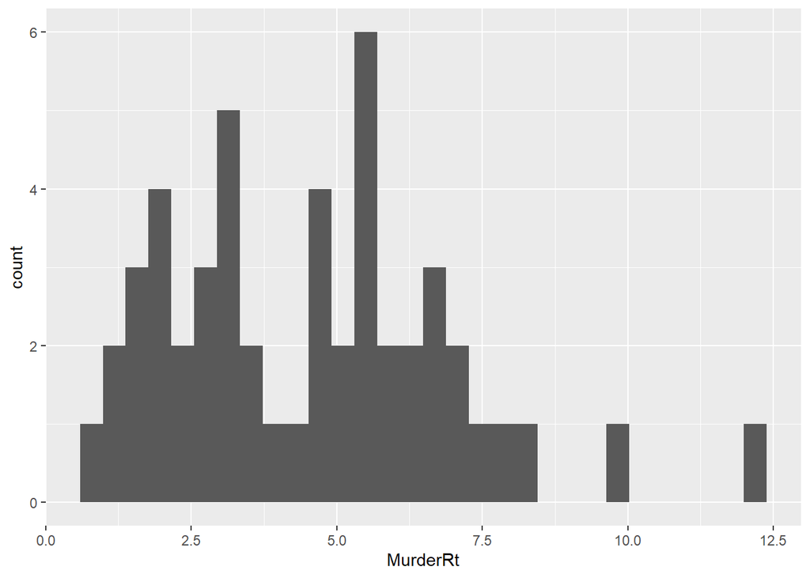

```r
#start by showing histogram for students (doing part of q5 for them)
StatesData %>%
  ggplot() +
  geom_histogram(aes(x=MurderRt))
```

2. Next, we are going to create a new column (variable) in which we convert ‘MurderRt’ variable values into z-score standardized values. Recall from this week’s readings and other course materials that the z-score allows us to make standardized comparisons about how close or far away a particular value (e.g., a state’s homicide rate) is from the mean of the data series (e.g., sample mean homicide rate across states). For example, we can see how close the homicide rates of states like Texas or California are to the sample-average US homicide rate.
   1. Create a third-level header titled: “Converting ‘MurderRt’ Values to Z-scores”
   2. Insert an R chunk, then select only the columns we need - “State” & “MurderRt” - and assign only these two variables (columns) into a new data object.
      - You know how to do this already - just follow the format: `datasubset <- data %>% dplyr::select(var1, var2)`. Try doing it yourself; if you get tripped up, that is fine. We include step-by-step instructions below as usual.
      - *Note:* While this step is not strictly necessary, it is often easier to work with just the subset of data that we need rather than the entire data object.
   3. Type `StatesDataSub <- StatesData %>%`.
      - We start by assigning our States data into a States data subset. At this point, `StatesDataSub` and `StatesData` are identical.
   4. Hit enter and type `select(State, MurderRt)`.
      - Here, we are selecting just the “State” and “MurderRt” variables. After this line, the `StatesDataSub` data object will contain only these two variables.
   5. To view your new data object with just the “State” and “MurderRt” variables, type `StatesDataSub` in the R chunk. Your Rstudio session should look something like this (but with header lines and descriptive text):

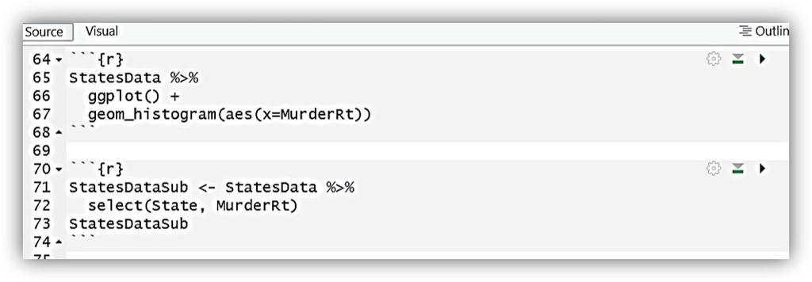

Selecting ‘State’ & ‘MurderRt’ Variables

```r
#select only the variable(s) we need & assign to new df
StatesDataSub <- StatesData %>%
  select(State, MurderRt)

StatesDataSub %>%
  descr(MurderRt)
```

```
## Descriptive Statistics
## StatesDataSub$MurderRt
## Label: Murder Rate per 100K
## N: 50
##
##                     MurderRt
## ----------------- ----------
##              Mean       4.51
##           Std.Dev       2.41
##               Min       0.90
##                Q1       2.60
##            Median       4.65
##                Q3       6.00
##               Max      12.30
##               MAD       2.59
##               IQR       3.35
##                CV       0.53
##          Skewness       0.73
##       SE.Skewness       0.34
##          Kurtosis       0.59
##           N.Valid      50.00
##         Pct.Valid     100.00
```

```r
  #note mean = 4.51, sd=2.41

#manually covert z-scores
StatesDataSub <- StatesDataSub %>%
  mutate(
    ZMurderRt = (MurderRt - 4.51)/2.41)
StatesDataSub %>% head() %>% gt()
```

| State | MurderRt | ZMurderRt |
| --- | --- | --- |
| Alabama | 7.1 | 1.0746888 |
| Alaska | 3.2 | -0.5435685 |
| Arizona | 5.5 | 0.4107884 |
| Arkansas | 6.3 | 0.7427386 |
| California | 5.4 | 0.3692946 |
| Colorado | 3.2 | -0.5435685 |

```r
#find z-score for each data value
StatesDataSub <- StatesDataSub %>%
  mutate(
    ZMurderRt = (MurderRt - mean(MurderRt))/sd(MurderRt)
    )
StatesDataSub %>% head() %>% gt()
```

| State | MurderRt | ZMurderRt |
| --- | --- | --- |
| Alabama | 7.1 | 1.0727213 |
| Alaska | 3.2 | -0.5450719 |
| Arizona | 5.5 | 0.4090113 |
| Arkansas | 6.3 | 0.7408663 |
| California | 5.4 | 0.3675294 |
| Colorado | 3.2 | -0.5450719 |

8. Finally, we will show you one way to create a function to convert variables to z-scores. This method is optional for the assignment, but feel free to give it a try! Remember, writing a function can be quite useful if you find that you need to standardize more than one variable. In general, any time you find yourself copying and pasting to perform a task, you should consider creating a function instead. See [here](https://r4ds.had.co.nz/functions.html) for more information about functions in R.

```r
# Let's try a function!
funxtoz = function(x){(x-mean(x))/sd(x)}

# Check to make sure it works. Do the values match those from previous method?
funxtoz(StatesDataSub$MurderRt)
```

```
##  [1]  1.07272133 -0.54507186  0.40901130  0.74086632  0.36752943 -0.54507186
##  [7] -0.62803561  0.03567441  0.40901130  0.61642069 -1.12581813 -1.25026376
## [13]  1.61198573  0.32604755 -1.33322751  0.07715629 -0.08877122  3.22977891
## [19] -1.04285438  1.32161259 -0.75248124  0.74086632 -1.25026376  0.98975758
## [25]  0.86531195 -0.54507186 -0.83544500  0.57493881 -1.49915502 -0.33766248
## [31]  2.27569575 -0.21321685  0.36752943 -1.04285438  0.20160192  0.82383007
## [37] -0.91840875  0.36752943 -0.62803561  0.90679382 -0.37914435  1.19716696
## [43]  0.36752943 -1.29174564 -1.33322751  0.07715629 -0.71099937  0.16012004
## [49] -0.79396312 -1.04285438
## attr(,"label")
## [1] "Murder Rate per 100K"
## attr(,"format.spss")
## [1] "F8.2"
```

```r
# Incorporate function into our mutate() code

StatesDataSub <- StatesDataSub %>%
  mutate(
    ZMurderRt = funxtoz(StatesDataSub$MurderRt)
    )
StatesDataSub %>% head() %>% gt()
```

| State | MurderRt | ZMurderRt |
| --- | --- | --- |
| Alabama | 7.1 | 1.0727213 |
| Alaska | 3.2 | -0.5450719 |
| Arizona | 5.5 | 0.4090113 |
| Arkansas | 6.3 | 0.7408663 |
| California | 5.4 | 0.3675294 |
| Colorado | 3.2 | -0.5450719 |

### Assignment 6 Objective Checks

#### After completing assignment #6…

- do you understand basic elements of a contingency table (aka crosstab)?
  - do you understand why it can be helpful to place IV in columns and DV in rows?
  - do you recognize column/row marginals and their overlap with univariate frequency distributions
  - do you know how to calculate marginal, conditional, and joint (frequentist) probabilities?
  - do you know how to compare column percentages (when an IV is in columns of a crosstab)?
- do you recognize the R operator `!=` as “not equal to”?
- do you know how to turn off or change scientific notation in R, such as `options(scipen=999, digits = 3)`?
- are you able to remove missing observations from a variable in R using `filter(!is.na(var))`?
- do you know how to change a numeric variable to a factor (e.g., nominal or ordinal) variable with `haven::as_factor()`?
  - do you recognize how to drop an unused factor level (e.g., missing “Don’t know” label) on a variable using `data %>% droplevels(data$variable)`?
- are you able to generate a crosstab in R using `dplyr::select()` & `sjPlot::sjtab(depvar, indepvar)`?
  - do you know how to add a title and column percents to `sjtab()` table and switch output from viewer to html browser?
- are you able to generate a crosstab in R using `crosstable(depvar, by=indepvar)`?
  - do you know how to include missing data and add column/row marginal frequency totals to a `crosstable()` table?
  - do you know how to modify decimal digits & table output format in `crosstable()` table, and how to output it to an aesthetically pleasing html table?
- do you understand the bimomial hypothesis test and how to conduct one in R?
  - do you understand the basic inputs of a binomial hypothesis test (p, x, *α*, & n)?
- are you able to modify elements of a `gt()` table, such as adding titles/subtitles with Markdown-formatted (e.g., `**bold**` or `*italicized*`) fonts?
- do you have a basic understanding of the logic behind null hypothesis significance testing?
  - do you understand alpha or significance level (e.g., as risk tolerance or false positive error control rate)?
  - do you know how to compare a test *p*-value to alpha level and appropriately decide whether to reject/fail to reject the null hypothesis?
- are you able to convert raw column (variable) values into standardized z-score values using `mutate()`?
- do you know that you can create your own R functions (e.g., our `funxtoz()` function) - and that doing so is recommended for duplicate tasks to avoid copy-and-paste errors?